# Case Study 2

Michael Burgess

3/24/2021

```r
library(tidyverse)
library(e1071)
library(caret)
```

```r
library(corrplot)
library(class)
library(vcd)
library(olsrr)
library(MPV)
library(cowplot)
```

# Youtube Presentation

## [Click Here For Presentation](https://youtu.be/MmvPaYlUu78)

# Introduction and Executive Summary

### In this case study, I was asked by my client, DDSAnalytics, to explore factors leading to attrition. DDSAnalytics specializes in talent

### management and is looking to leverage data science in this capacity. Their executive leadership would like to perform an analysis on existing

### data before green lighting a larger project.

### Using ROC analysis of Naive Bayes on a undersampling of the data, it was determined that the top 3 contributors to employee turnover were

### Overtime, Monthly Income, and Total Years Worked. Using these variables only, it was possible to determine whether an employee would

### experience attrition with an overall accuracy of approximately 71%.

### Further, I was also asked to identify the top 3 variables contributing to employees’ monthly income. Using different automatic variable

### selection techniques on a linear regression model I determined that the top 3 variables were Job Level, Job Role, and Total Working Years.

### Using a linear model created with these variables I was able to predict the mean monthly income for an employee with an accuracy of plus or ### minus $986.70 and to account for approximately 95.4% of the variation in the means of monthly income.

## Code and Analysis

### First I imported the Employee Data. It does not contain any missing entries. I then dropped unnecessary columns: the Employee ID numbers,

### Employee Count as that was 1 for all entries, Employee Number, Over 18 as all employees were over 18, and Standard Hours as all Standard

```r
#Data Import
EmpData <- read.csv(choose.files(), header = T, sep = ",")

#Remove Employee ID Numbers, over 18 as all employees are over 18, and Standard hours as all standard hours are 80
EmpData <- EmpData[,-c(1, 10, 11, 23, 28)]

#Convert characters to factors
EmpData[sapply(EmpData, is.character)] <- lapply(EmpData[sapply(EmpData, is.character)],
                                       as.factor)

#Check for NAs
map(EmpData, ~sum(is.na(.)))
```

```
## $Age
## [1] 0
##
## $Attrition
## [1] 0
##
## $BusinessTravel
## [1] 0
##
## $DailyRate
## [1] 0
##
## $Department
## [1] 0
##
## $DistanceFromHome
## [1] 0
##
## $Education
## [1] 0
##
## $EducationField
## [1] 0
##
## $EnvironmentSatisfaction
## [1] 0
##
## $Gender
## [1] 0
##
## $HourlyRate
## [1] 0
##
## $JobInvolvement
## [1] 0
##
## $JobLevel
## [1] 0
##
## $JobRole
```

[output cut: 37 more lines]

```
##
## $WorkLifeBalance
## [1] 0
##
## $YearsAtCompany
## [1] 0
##
## $YearsInCurrentRole
## [1] 0
##
## $YearsSinceLastPromotion
## [1] 0
##
## $YearsWithCurrManager
## [1] 0
```

```r
#Check number of levels for each factor
str(EmpData)
```

```
## 'data.frame':    870 obs. of  31 variables:
##  $ Age                     : int  32 40 35 32 24 27 41 37 34 34 ...
##  $ Attrition               : Factor w/ 2 levels "No","Yes": 1 1 1 1 1 1 1 1 1 1 ...
##  $ BusinessTravel          : Factor w/ 3 levels "Non-Travel","Travel_Frequently",..: 3 3 2 3 2 2 3 3 3 2 ...
##  $ DailyRate               : int  117 1308 200 801 567 294 1283 309 1333 653 ...
##  $ Department              : Factor w/ 3 levels "Human Resources",..: 3 2 2 3 2 2 2 3 3 2 ...
##  $ DistanceFromHome        : int  13 14 18 1 2 10 5 10 10 10 ...
##  $ Education               : int  4 3 2 4 1 2 5 4 4 4 ...
##  $ EducationField          : Factor w/ 6 levels "Human Resources",..: 2 4 2 3 6 2 4 2 2 6 ...
##  $ EnvironmentSatisfaction : int  2 3 3 3 1 4 2 4 3 4 ...
##  $ Gender                  : Factor w/ 2 levels "Female","Male": 2 2 2 1 1 2 2 1 1 2 ...
##  $ HourlyRate              : int  73 44 60 48 32 32 90 88 87 92 ...
##  $ JobInvolvement          : int  3 2 3 3 3 3 4 2 3 2 ...
##  $ JobLevel                : int  2 5 3 3 1 3 1 2 1 2 ...
##  $ JobRole                 : Factor w/ 9 levels "Healthcare Representative",..: 8 6 5 8 7 5 7 8 9 1 ...
```

[output cut: 17 more lines]

```r
#convert more columns for int to factor
EmpData$Education <- as.factor(EmpData$Education)
EmpData$JobInvolvement <- as.factor(EmpData$JobInvolvement)
EmpData$JobLevel <- as.factor(EmpData$JobLevel)
EmpData$JobSatisfaction <- as.factor(EmpData$JobSatisfaction)
EmpData$PerformanceRating <- as.factor(EmpData$PerformanceRating)
EmpData$RelationshipSatisfaction <- as.factor(EmpData$RelationshipSatisfaction)
EmpData$StockOptionLevel <- as.factor(EmpData$StockOptionLevel)
EmpData$WorkLifeBalance <- as.factor(EmpData$WorkLifeBalance)
```

## Identifying Factors That Contribute to Attrition

### One of the issues with this dataset is that it is very unbalanced. Only about 16% of the data contains a yes value attrition, so for any

### model it could identify everything as no attrition and still be approximately 84% - 85% accurate. To work around this I used a technique

### called under sampling. I first split the data set into the 140 rows containing yes for attrition and then a seperate dataframe contaning

### the no values. I then randomly sampled 140 of the no rows and combined them with the 140 yes rows. I then ran a Naive-Bayes classifier

### with Leave One Out Cross Validation on the combined dataframe and saved the top 3 variables that contributed to the attrition. I repeated this

### process 100 times, saving the top 3 variables each time. Using this process Overtime, Monthly Income, and Total Years Worked were

### identified as the top 3 variables contributing to attrition. This makes sense as we would except employees that feel overworked or underpaid ### to have higher levels of attrition.

```r
#split dataframe into separate frames for yes and no attrition
AtrYes = EmpData %>% filter(Attrition == "Yes")
AtrNo = EmpData %>% filter(Attrition == "No")

Grid = data.frame(usekernel=TRUE,laplace = 1,adjust=1)

#create dataframe to hold most important variables
ImpName <- data.frame()

#run naive bayes with loocv 100 times and select 3 most important variables using ROC
#This testing uses under sampling in which 140 random no attrition values are selected to
#compare to the 140 yes attrition values in the original Employee Data
for(i in 1:100){
  AtrNoSample = sample_n(AtrNo, 140)
  AtrDF <- data.frame()
  AtrDF = rbind(AtrYes, AtrNoSample)

  mdl = train(Attrition ~ .,data=AtrDF,method="naive_bayes",
              trControl=trainControl(method="LOOCV"),
              tuneGrid=Grid)

  ImpMeasure<-data.frame(varImp(mdl)$importance)
  ImpMeasure$Name<-row.names(ImpMeasure)
  ImpMeasure <- ImpMeasure[order(-ImpMeasure$Yes),]
  ImpMeasure <- ImpMeasure[1:3,] %>% select(Name)
  rownames(ImpMeasure) <- NULL
  ImpName <- rbind(ImpName, ImpMeasure)
}
```

## Predicting Attrition with the Top 3 Influential Factors

### After the top 3 variables were identified I created a data frame with the same information as the Employee Data, but with only those

### variables and whether or not they experienced attrition. I ran the undersampled Naive-Bayes test on the full Employee Data 100 times using

### different samples of no attrition employees and then averaged the accuracy, sensitivity, and specificity. I was able to achieve an average

### accuracy of 71%. No attrition was identified correctly an average 72% of the time and yes attrition was identifed correctly an

### average 64% of the time.

```r
#Create data frame with only the 3 most influential variables from EmpData: Overtime, Monthly Income, and Total Working Years
AtrNB <- data.frame(MonthlyIncome = EmpData$MonthlyIncome, OverTime = EmpData$OverTime,
                    TotalWorkingYears= EmpData$TotalWorkingYears, Attrition = EmpData$Attrition)

AtrYesNB = AtrNB %>% filter(Attrition == "Yes")
AtrNoNB = AtrNB %>% filter(Attrition == "No")

iterations = 100

masterAcc = matrix(nrow = iterations)
masterSen = matrix(nrow = iterations)
masterSpe = matrix(nrow = iterations)

for(j in 1:iterations)
{
  AtrNoSampleNB = sample_n(AtrNoNB, 140)
  AtrDFNB <- data.frame()
  AtrDFNB = rbind(AtrYesNB, AtrNoSampleNB)
  mdlNB = train(Attrition~., data = AtrDFNB, "naive_bayes", trControl=trainControl(method="LOOCV"), tuneGrid = Grid)
  predict = predict(mdlNB, newdata = EmpData)
  CM = confusionMatrix(predict, EmpData$Attrition)
  masterAcc[j] = CM$overall[1]
  masterSen[j] = CM$byClass[1]
  masterSpe[j] = CM$byClass[2]
}

MeanAcc = colMeans(masterAcc)

masterSen[is.na(masterSen)] = 0
MeanSen = colMeans(masterSen)

masterSpe[is.na(masterSpe)] = 0
MeanSpe = colMeans(masterSpe)

MeanAcc
```

```
## [1] 0.7157816
```

```r
MeanSen
```

```
## [1] 0.7292055
```

```r
MeanSpe
```

```
## [1] 0.6457857
```

## Predictions for Dataset with no Attrition

### I was also provided a dataset with no attrition information and requested to predcit whether or not those employees experienced attrition.

### I used a similar undersampled model and saved the predictions to a csv file.

```r
#import the competition data set that has no attrition labels
compData <- read.csv(choose.files(), header = T, sep = ",")
compData[sapply(compData, is.character)] <- lapply(compData[sapply(compData, is.character)],
                                       as.factor)

#run naive-bayes model again and confirm accuracy
AtrNB <- data.frame(MonthlyIncome = EmpData$MonthlyIncome, OverTime = EmpData$OverTime,
                    TotalWorkingYears= EmpData$TotalWorkingYears, Attrition = EmpData$Attrition)

AtrYesNB = AtrNB %>% filter(Attrition == "Yes")
AtrNoNB = AtrNB %>% filter(Attrition == "No")

AtrNoSampleNB = sample_n(AtrNoNB, 140)
AtrDFNB <- data.frame()
AtrDFNB = rbind(AtrYesNB, AtrNoSampleNB)
mdlNB = train(Attrition~., data = AtrDFNB, "naive_bayes", trControl=trainControl(method="LOOCV"), tuneGrid = Grid)

predict = predict(mdlNB, newdata = EmpData)
CM = confusionMatrix(predict, EmpData$Attrition)


#run predictions for attrition labels for competition set
predictComp = predict(mdlNB, newdata = compData)
finalCompDF <- data.frame(ID = compData$ID, Attrition = predictComp)

#save the competition predictions to a csv
write.csv(finalCompDF, file = choose.files())
```

## Other Insights

### Because Overtime, Monthly Income, and Total Years worked were the 3 most influential variables for employee attrition, I wanted to look deeper

### at these variables. First I looked at attrition by job role and found that Sales Representatives has an attrition rate of over 45%. Looking at

### the overtime and monthly income for Sales Representatives I found that over 33% of Sales Representatives had worked overtime and that only 1

### sales representative had a monthly income of over $5,000.00. Human Resources experienced the next highest attrition at 22.22%, but had the ### 3rd lowest overtime rate at 22.22%. However, we again see that the majority of Human Resources monthly incomes was below $5,000.00.

### Comparatively, Research Directors had the lowest attrition at only 1.96% but the third highest Overtime rate of 31.37% However, Research

### Directors also had some of the highest total working years and monthly incomes with only a few employees having less than 10 years of

### experience and all monthly income rates above $10,000.Interestingly attrition was the highest for employees with less than 10 total working ### years of experience with the highest rates between 0 to 5 years. There were fewer employees experiencing attrition between 10 to 20 years and ### almost none above 20. We also see that the majority of employees with attrition made a monthly income fewer than $5,000.

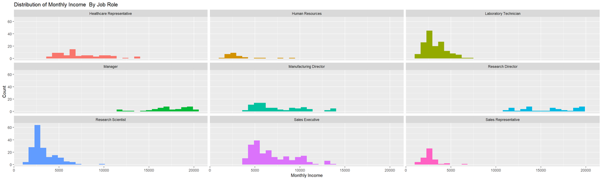

```r
#create table of attrition by job role
tab <- table(EmpData$JobRole, EmpData$Attrition)
tab <- cbind(tab, Total = rowSums(tab))

#convert to data frame and add percentage of how many employees were yes or no attrition by job role
JobAtrDF <- as.data.frame.matrix(tab)
JobAtrDF$Percent_No <- round((JobAtrDF$No/JobAtrDF$Total)*100, 2)
JobAtrDF$Percent_Yes <- round((JobAtrDF$Yes/JobAtrDF$Total)*100, 2)
JobAtrDF <- JobAtrDF[order(-JobAtrDF$Percent_Yes),]

#table of overtime by job role
tab2 <- table(EmpData$JobRole, EmpData$OverTime)
tab2 <- cbind(tab2, Total = rowSums(tab2))

#convert to dataframe and add percentage of how many employees were yes or no overtime by job role
JobOvrDF <- as.data.frame.matrix(tab2)
JobOvrDF$Percent_No <- round((JobOvrDF$No/JobOvrDF$Total)*100, 2)
JobOvrDF$Percent_Yes <- round((JobOvrDF$Yes/JobOvrDF$Total)*100, 2)
JobOvrDF <- JobOvrDF[order(-JobOvrDF$Percent_Yes),]

#Monthly income by job role histogram
EmpData %>% ggplot(aes(x = MonthlyIncome, fill = JobRole)) + geom_histogram(show.legend = FALSE) + facet_wrap(~JobRole) +
    labs(title = "Distribution of Monthly Income  By Job Role", x = "Monthly Income", y = "Count")
```

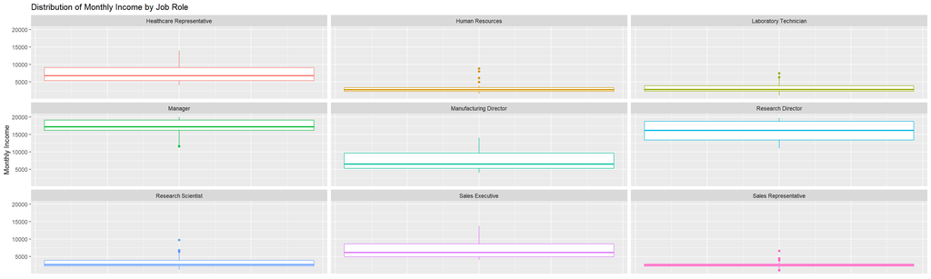

```r
#Monthly income by job role boxplot
EmpData %>% ggplot(aes(y = MonthlyIncome, color = JobRole)) + geom_boxplot(show.legend = FALSE) + facet_wrap(~JobRole) +
  labs(title = "Distribution of Monthly Income by Job Role", y = "Monthly Income") +
  theme(axis.title.x=element_blank(),axis.text.x=element_blank(), axis.ticks.x=element_blank())
```

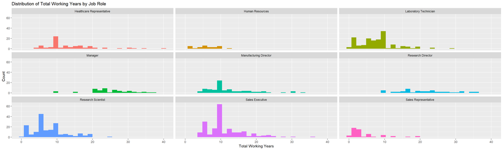

```r
#total working years by job role histogram
EmpData %>% ggplot(aes(x = TotalWorkingYears, fill = JobRole)) + geom_histogram(show.legend = FALSE) + facet_wrap(~JobRole) +
  labs(title = "Distribution of Total Working Years by Job Role", x = "Total Working Years", y = "Count")
```

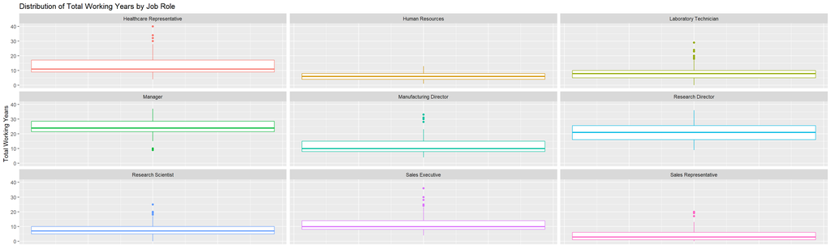

```r
#total working years by job role boxpot
EmpData %>% ggplot(aes(y = TotalWorkingYears, color = JobRole)) + geom_boxplot(show.legend = FALSE) + facet_wrap(~JobRole) +
  labs(title = "Distribution of Total Working Years by Job Role", y = "Total Working Years") +
  theme(axis.title.x=element_blank(),axis.text.x=element_blank(), axis.ticks.x=element_blank())
```

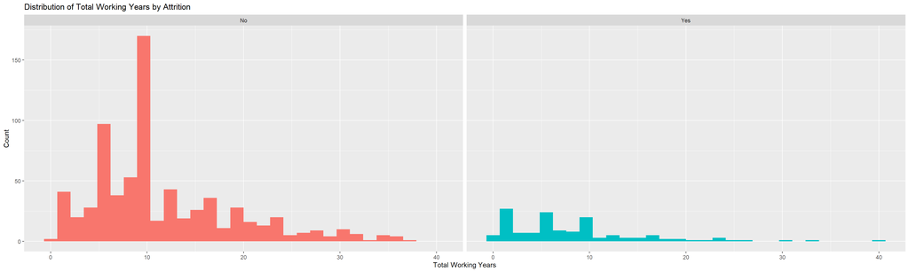

```r
#attrition by total working years
EmpData %>% ggplot(aes(x = TotalWorkingYears, fill = Attrition)) + geom_histogram(show.legend = FALSE) + facet_wrap(~Attrition) +
  labs(title = "Distribution of Total Working Years by Attrition", x = "Total Working Years", y = "Count")
```

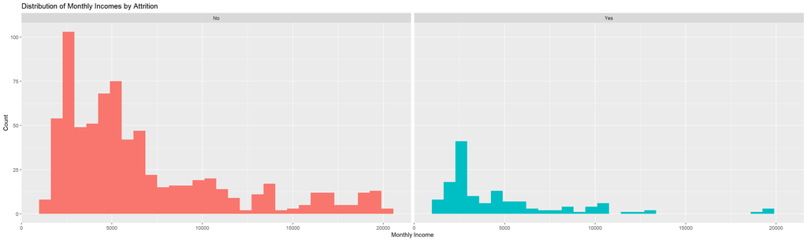

```r
#attrition by monthly income
EmpData %>% ggplot(aes(x = MonthlyIncome, fill = Attrition)) + geom_histogram(show.legend = FALSE) + facet_wrap(~Attrition) +
  labs(title = "Distribution of Monthly Incomes by Attrition", x = "Monthly Income", y = "Count")
```

## Predict Monthly Income

### I used 3 different selection models to find the top 3 most influential variables for predicting monthly income. Job Level, Job Role, and Total

```r
#Create model contaning all variables to predict monthly income
IncomeMdl <- lm(MonthlyIncome ~ ., data = EmpData)

#create dataframe and model containing variables selected by Forward Selection
SelectForward <- ols_step_forward_p(IncomeMdl, peneter = 0.05, details = FALSE)
VarFoward <- SelectForward$predictors
ForwardDF <- EmpData %>% select(VarFoward, MonthlyIncome)
```

```
## Note: Using an external vector in selections is ambiguous.
## i Use `all_of(VarFoward)` instead of `VarFoward` to silence this message.
## i See <https://tidyselect.r-lib.org/reference/faq-external-vector.html>.
```

```r
MdlFrwrd <- lm(MonthlyIncome ~ . , data = ForwardDF)

summary(MdlFrwrd)
```

```
##
## Call:
## lm(formula = MonthlyIncome ~ ., data = ForwardDF)
##
## Residuals:
##     Min      1Q  Median      3Q     Max
## -3304.0  -625.1   -64.7   594.6  4204.2
##
## Coefficients:
##                                    Estimate Std. Error t value Pr(>|t|)
## (Intercept)                       2.703e+03  5.308e+02   5.092 4.37e-07 ***
## JobLevel2                         1.729e+03  1.398e+02  12.365  < 2e-16 ***
## JobLevel3                         4.969e+03  1.869e+02  26.586  < 2e-16 ***
## JobLevel4                         8.343e+03  2.835e+02  29.429  < 2e-16 ***
## JobLevel5                         1.095e+04  3.332e+02  32.882  < 2e-16 ***
## JobRoleHuman Resources           -8.480e+02  4.873e+02  -1.740  0.08218 .
## JobRoleLaboratory Technician     -1.205e+03  1.744e+02  -6.911 9.46e-12 ***
## JobRoleManager                    3.652e+03  2.810e+02  12.998  < 2e-16 ***
## JobRoleManufacturing Director     1.368e+02  1.575e+02   0.868  0.38551
## JobRoleResearch Director          3.530e+03  2.117e+02  16.673  < 2e-16 ***
## JobRoleResearch Scientist        -1.003e+03  1.778e+02  -5.640 2.33e-08 ***
## JobRoleSales Executive            5.591e+02  3.355e+02   1.667  0.09596 .
## JobRoleSales Representative      -6.758e+02  3.775e+02  -1.790  0.07381 .
## TotalWorkingYears                 4.468e+01  7.778e+00   5.744 1.29e-08 ***
## BusinessTravelTravel_Frequently   2.248e+02  1.319e+02   1.704  0.08870 .
## BusinessTravelTravel_Rarely       3.486e+02  1.117e+02   3.122  0.00186 **
## DailyRate                         1.748e-01  8.522e-02   2.051  0.04057 *
## Education2                       -2.802e+01  1.264e+02  -0.222  0.82457
## Education3                       -8.934e+01  1.165e+02  -0.767  0.44318
## Education4                        6.012e+01  1.228e+02   0.490  0.62458
## Education5                       -4.154e+02  2.266e+02  -1.833  0.06717 .
## DepartmentResearch & Development  2.315e+02  4.176e+02   0.554  0.57943
## DepartmentSales                  -3.337e+02  4.269e+02  -0.782  0.43462
## GenderMale                        8.290e+01  6.967e+01   1.190  0.23444
## PerformanceRating4               -2.630e+02  1.519e+02  -1.731  0.08375 .
## PercentSalaryHike                 1.888e+01  1.482e+01   1.274  0.20305
## DistanceFromHome                 -4.735e+00  4.214e+00  -1.124  0.26150
## ---
## Signif. codes:  0 '***' 0.001 '**' 0.01 '*' 0.05 '.' 0.1 ' ' 1
##
## Residual standard error: 996.7 on 843 degrees of freedom
## Multiple R-squared:  0.9544, Adjusted R-squared:  0.953
## F-statistic: 678.8 on 26 and 843 DF,  p-value: < 2.2e-16
```

```r
#create dataframe and model containing variables selected by Backward Selection
SelectBackward <- ols_step_backward_p(IncomeMdl, peneter = 0.05, details = FALSE)
MdlBackward <- lm(MonthlyIncome ~ JobLevel + JobRole + TotalWorkingYears + BusinessTravel + Gender +
                    DailyRate + MonthlyRate + YearsWithCurrManager + YearsSinceLastPromotion +
                    DistanceFromHome + PerformanceRating + PercentSalaryHike + Department, data = EmpData)

summary(MdlBackward)
```

```
##
## Call:
## lm(formula = MonthlyIncome ~ JobLevel + JobRole + TotalWorkingYears +
##     BusinessTravel + Gender + DailyRate + MonthlyRate + YearsWithCurrManager +
##     YearsSinceLastPromotion + DistanceFromHome + PerformanceRating +
##     PercentSalaryHike + Department, data = EmpData)
##
## Residuals:
##     Min      1Q  Median      3Q     Max
## -3362.7  -618.9   -61.5   580.1  4226.4
##
## Coefficients:
##                                    Estimate Std. Error t value Pr(>|t|)
## (Intercept)                       2.734e+03  5.270e+02   5.188 2.67e-07 ***
## JobLevel2                         1.747e+03  1.410e+02  12.393  < 2e-16 ***
## JobLevel3                         4.956e+03  1.890e+02  26.229  < 2e-16 ***
## JobLevel4                         8.252e+03  2.823e+02  29.230  < 2e-16 ***
## JobLevel5                         1.091e+04  3.334e+02  32.727  < 2e-16 ***
## JobRoleHuman Resources           -8.842e+02  4.887e+02  -1.809  0.07074 .
## JobRoleLaboratory Technician     -1.199e+03  1.756e+02  -6.826 1.67e-11 ***
## JobRoleManager                    3.686e+03  2.817e+02  13.087  < 2e-16 ***
## JobRoleManufacturing Director     1.438e+02  1.581e+02   0.910  0.36318
## JobRoleResearch Director          3.541e+03  2.134e+02  16.596  < 2e-16 ***
## JobRoleResearch Scientist        -1.011e+03  1.784e+02  -5.666 2.01e-08 ***
## JobRoleSales Executive            5.570e+02  3.363e+02   1.656  0.09803 .
## JobRoleSales Representative      -6.707e+02  3.787e+02  -1.771  0.07695 .
## TotalWorkingYears                 4.569e+01  8.374e+00   5.456 6.40e-08 ***
## BusinessTravelTravel_Frequently   2.043e+02  1.321e+02   1.547  0.12217
## BusinessTravelTravel_Rarely       3.458e+02  1.120e+02   3.089  0.00207 **
## GenderMale                        8.131e+01  6.994e+01   1.163  0.24531
## DailyRate                         1.730e-01  8.555e-02   2.023  0.04344 *
## MonthlyRate                      -4.352e-03  4.849e-03  -0.897  0.36976
## YearsWithCurrManager             -7.670e+00  1.210e+01  -0.634  0.52647
## YearsSinceLastPromotion           1.215e+01  1.326e+01   0.916  0.35980
## DistanceFromHome                 -5.144e+00  4.216e+00  -1.220  0.22275
## PerformanceRating4               -2.837e+02  1.519e+02  -1.868  0.06207 .
## PercentSalaryHike                 2.116e+01  1.484e+01   1.426  0.15411
## DepartmentResearch & Development  2.018e+02  4.188e+02   0.482  0.63007
## DepartmentSales                  -3.586e+02  4.278e+02  -0.838  0.40214
## ---
## Signif. codes:  0 '***' 0.001 '**' 0.01 '*' 0.05 '.' 0.1 ' ' 1
##
## Residual standard error: 999.1 on 844 degrees of freedom
## Multiple R-squared:  0.9541, Adjusted R-squared:  0.9528
## F-statistic: 702.4 on 25 and 844 DF,  p-value: < 2.2e-16
```

```r
#create dataframe and model containing varaibles selected by Stepwise Selection
SelectStep <- ols_step_both_p(IncomeMdl, peneter = 0.05, details = FALSE)

VarStep <- SelectStep$predictors
StepDF <- EmpData %>% select(VarStep, MonthlyIncome)
```

```
## Note: Using an external vector in selections is ambiguous.
## i Use `all_of(VarStep)` instead of `VarStep` to silence this message.
## i See <https://tidyselect.r-lib.org/reference/faq-external-vector.html>.
```

```r
MdlStep <- lm(MonthlyIncome ~ . , data = StepDF)

summary(MdlStep)
```

```
##
## Call:
## lm(formula = MonthlyIncome ~ ., data = StepDF)
##
## Residuals:
##     Min      1Q  Median      3Q     Max
## -3188.6  -631.5   -93.0   607.1  4097.1
##
## Coefficients:
##                                   Estimate Std. Error t value Pr(>|t|)
## (Intercept)                      3.192e+03  2.165e+02  14.747  < 2e-16 ***
## JobLevel2                        1.706e+03  1.386e+02  12.312  < 2e-16 ***
## JobLevel3                        4.932e+03  1.861e+02  26.497  < 2e-16 ***
## JobLevel4                        8.262e+03  2.811e+02  29.397  < 2e-16 ***
## JobLevel5                        1.095e+04  3.310e+02  33.075  < 2e-16 ***
## JobRoleHuman Resources          -1.115e+03  2.512e+02  -4.438 1.03e-05 ***
## JobRoleLaboratory Technician    -1.231e+03  1.745e+02  -7.053 3.61e-12 ***
## JobRoleManager                   3.376e+03  2.373e+02  14.229  < 2e-16 ***
## JobRoleManufacturing Director    1.171e+02  1.577e+02   0.743  0.45793
## JobRoleResearch Director         3.499e+03  2.105e+02  16.619  < 2e-16 ***
## JobRoleResearch Scientist       -1.027e+03  1.777e+02  -5.780 1.05e-08 ***
## JobRoleSales Executive          -1.236e+01  1.360e+02  -0.091  0.92762
## JobRoleSales Representative     -1.245e+03  2.203e+02  -5.650 2.18e-08 ***
## TotalWorkingYears                4.544e+01  7.722e+00   5.885 5.72e-09 ***
## BusinessTravelTravel_Frequently  1.916e+02  1.318e+02   1.453  0.14655
## BusinessTravelTravel_Rarely      3.351e+02  1.117e+02   3.001  0.00277 **
## DailyRate                        1.785e-01  8.521e-02   2.095  0.03644 *
## ---
## Signif. codes:  0 '***' 0.001 '**' 0.01 '*' 0.05 '.' 0.1 ' ' 1
##
## Residual standard error: 1001 on 853 degrees of freedom
## Multiple R-squared:  0.9535, Adjusted R-squared:  0.9526
## F-statistic:  1093 on 16 and 853 DF,  p-value: < 2.2e-16
```

```r
#All three models agree on job level, job role, and total working years as most significant
#Create model using these 3 variables

LmModel <- lm(MonthlyIncome ~ JobLevel + JobRole + TotalWorkingYears, data = EmpData)
summary(LmModel)
```

```
##
## Call:
## lm(formula = MonthlyIncome ~ JobLevel + JobRole + TotalWorkingYears,
##     data = EmpData)
##
## Residuals:
##     Min      1Q  Median      3Q     Max
## -3184.4  -622.9   -83.6   623.4  4282.9
##
## Coefficients:
##                                Estimate Std. Error t value Pr(>|t|)
## (Intercept)                    3620.912    180.824  20.025  < 2e-16 ***
## JobLevel2                      1687.533    139.069  12.134  < 2e-16 ***
## JobLevel3                      4913.569    186.878  26.293  < 2e-16 ***
## JobLevel4                      8246.787    282.379  29.205  < 2e-16 ***
## JobLevel5                     11003.473    332.523  33.091  < 2e-16 ***
## JobRoleHuman Resources        -1106.211    252.764  -4.376 1.36e-05 ***
## JobRoleLaboratory Technician  -1243.528    175.324  -7.093 2.75e-12 ***
## JobRoleManager                 3332.134    237.808  14.012  < 2e-16 ***
## JobRoleManufacturing Director   134.719    158.506   0.850    0.396
## JobRoleResearch Director       3479.341    211.496  16.451  < 2e-16 ***
## JobRoleResearch Scientist     -1040.524    178.715  -5.822 8.21e-09 ***
## JobRoleSales Executive          -13.146    136.850  -0.096    0.923
## JobRoleSales Representative   -1267.454    220.601  -5.745 1.27e-08 ***
## TotalWorkingYears                45.975      7.768   5.918 4.70e-09 ***
## ---
## Signif. codes:  0 '***' 0.001 '**' 0.01 '*' 0.05 '.' 0.1 ' ' 1
##
## Residual standard error: 1007 on 856 degrees of freedom
## Multiple R-squared:  0.9527, Adjusted R-squared:  0.952
## F-statistic:  1327 on 13 and 856 DF,  p-value: < 2.2e-16
```

```r
LmModel2 <- lm(MonthlyIncome ~ JobLevel * JobRole * TotalWorkingYears, data = EmpData)
summary(LmModel2)
```

```
##
## Call:
## lm(formula = MonthlyIncome ~ JobLevel * JobRole * TotalWorkingYears,
##     data = EmpData)
##
## Residuals:
##     Min      1Q  Median      3Q     Max
## -3273.9  -596.5   -59.3   538.0  4322.7
##
## Coefficients: (40 not defined because of singularities)
##                                                             Estimate Std. Error
## (Intercept)                                                 1732.710   1905.464
## JobLevel2                                                   3440.162   1861.944
## JobLevel3                                                   6102.983   1960.657
## JobLevel4                                                  11404.894   2936.737
## JobLevel5                                                  13948.006   3351.443
## JobRoleHuman Resources                                       864.668   1953.963
## JobRoleLaboratory Technician                                 665.908   1912.938
## JobRoleManager                                              2766.002   2990.347
## JobRoleManufacturing Director                               -307.203   2981.323
## JobRoleResearch Director                                    3459.968   2371.125
## JobRoleResearch Scientist                                    769.193   1912.118
## JobRoleSales Executive                                      -896.756   2914.810
## JobRoleSales Representative                                  570.128   1895.945
## TotalWorkingYears                                            192.863    158.197
## JobLevel2:JobRoleHuman Resources                              41.951   1035.796
## JobLevel3:JobRoleHuman Resources                            7777.639  13426.270
## JobLevel4:JobRoleHuman Resources                                  NA         NA
## JobLevel5:JobRoleHuman Resources                                  NA         NA
## JobLevel2:JobRoleLaboratory Technician                      -328.024   1970.159
## JobLevel3:JobRoleLaboratory Technician                    -11871.213   5867.984
## JobLevel4:JobRoleLaboratory Technician                            NA         NA
## JobLevel5:JobRoleLaboratory Technician                            NA         NA
## JobLevel2:JobRoleManager                                          NA         NA
## JobLevel3:JobRoleManager                                    -613.384   3639.515
## JobLevel4:JobRoleManager                                     773.862   2348.981
## JobLevel5:JobRoleManager                                          NA         NA
## JobLevel2:JobRoleManufacturing Director                      544.776   3030.113
## JobLevel3:JobRoleManufacturing Director                       78.345   3059.891
## JobLevel4:JobRoleManufacturing Director                           NA         NA
```

[output cut: 143 more lines]

```
## JobLevel5:JobRoleResearch Scientist:TotalWorkingYears          NA       NA
## JobLevel2:JobRoleSales Executive:TotalWorkingYears         -0.630 0.529121
## JobLevel3:JobRoleSales Executive:TotalWorkingYears         -0.414 0.679258
## JobLevel4:JobRoleSales Executive:TotalWorkingYears             NA       NA
## JobLevel5:JobRoleSales Executive:TotalWorkingYears             NA       NA
## JobLevel2:JobRoleSales Representative:TotalWorkingYears        NA       NA
## JobLevel3:JobRoleSales Representative:TotalWorkingYears        NA       NA
## JobLevel4:JobRoleSales Representative:TotalWorkingYears        NA       NA
## JobLevel5:JobRoleSales Representative:TotalWorkingYears        NA       NA
## ---
## Signif. codes:  0 '***' 0.001 '**' 0.01 '*' 0.05 '.' 0.1 ' ' 1
##
## Residual standard error: 986.7 on 820 degrees of freedom
## Multiple R-squared:  0.9565, Adjusted R-squared:  0.9539
## F-statistic: 368.3 on 49 and 820 DF,  p-value: < 2.2e-16
```

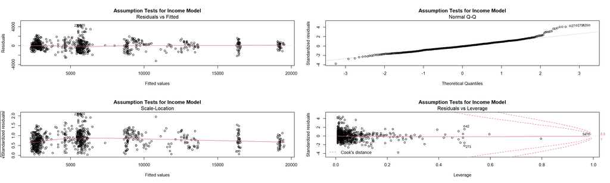

```r
par(mfrow = c(2,2))
plot(LmModel2, main = "Assumption Tests for Income Model")
```

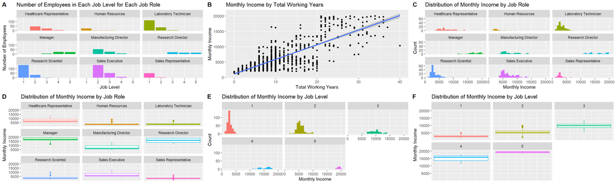

```r
par(mfrow = c(1,1))


#graphics for income and 3 variables

#income by total working years
IncomeByYears <- EmpData %>% ggplot(aes(x=TotalWorkingYears, y= MonthlyIncome)) + geom_point() + geom_smooth(method="lm") +
  labs(title = "Monthly Income by Total Working Years", x = "Total Working Years", y = "Monthly Income")

#distribution of job levels by job role
JobLevelRole <- EmpData %>% ggplot(aes(x=JobLevel, fill = JobRole)) + geom_bar(show.legend = FALSE) + facet_wrap(~JobRole) +
  labs(title = "Number of Employees in Each Job Level for Each Job Role", x = "Job Level", y = "Number of Employees")

#histogram and box plot for Monthly Income by Job Role
IncomeJobRoleHist <- EmpData %>% ggplot(aes(x=MonthlyIncome, fill = JobRole)) + geom_histogram(show.legend = FALSE) + facet_wrap(~JobRole) +
  labs(title = "Distribution of Monthly Income by Job Role", x = "Monthly Income", y = "Count")

IncomeJobRoleBox <- EmpData %>% ggplot(aes(y=MonthlyIncome, color = JobRole)) + geom_boxplot(show.legend = FALSE) + facet_wrap(~JobRole) +
  labs(title = "Distribution of Monthly Income by Job Role", y = "Monthly Income") +
  theme(axis.title.x=element_blank(),axis.text.x=element_blank(), axis.ticks.x=element_blank())

#histogram and box plot for Monthly Income by Job Level
IncomeJobLevelHist <- EmpData %>% ggplot(aes(x=MonthlyIncome, fill = JobLevel)) + geom_histogram(show.legend = FALSE) + facet_wrap(~JobLevel) +
  labs(titles = "Distribution of Monthly Income by Job Level", x = "Monthly Income", y = "Count")


IncomeJobLevelBox <- EmpData %>% ggplot(aes(y=MonthlyIncome, color = JobLevel)) + geom_boxplot(show.legend = FALSE) + facet_wrap(~JobLevel) +
  labs(titles = "Distribution of Monthly Income by Job Level", y = "Monthly Income") +
  theme(axis.title.x=element_blank(),axis.text.x=element_blank(), axis.ticks.x=element_blank())

plot_grid(JobLevelRole, IncomeByYears, IncomeJobRoleHist, IncomeJobRoleBox, IncomeJobLevelHist, IncomeJobLevelBox, labels = "AUTO")
```

## Predictions for Dataset with no Monthly Income

### I was also provided a dataset with no Monthly Income information and asked to predcit those monthly income values for each employee in the

### set. I used the Monthly Income model and saved the predictions to a csv file.

```r
#import the competition data set that has no income values
compIncomeData <- read.csv(choose.files(), header = T, sep = ",")
compIncomeData[sapply(compIncomeData, is.character)] <- lapply(compIncomeData[sapply(compIncomeData, is.character)],
                                       as.factor)


compIncomeData$JobLevel <- as.factor(compIncomeData$JobLevel)

#run predictions for income for competition set
predictIncome = predict(LmModel2, newdata = compIncomeData)
finalCompIncome <- data.frame(ID = compIncomeData$ID, MonthlyIncome = predictIncome)

#save the competition predictions to a csv
write.csv(finalCompIncome, file = choose.files())
```